# 16_quadratic_from_zeros

## 16_quadratic_from_zeros

#### Question

1. A quadratic polynomial, $f(x)$, is generated by randomly selecting two parameters, $B$ and $C$, in the equation below.

   $$f(x)~=~x^2+Bx+C$$

   Notice the leading coefficient (of the quadratic term) is 1. However the linear coefficient and the constant are randomly determined.

   When $y=f(x)$ is graphed below, you notice it has zeros (roots, $x$-intercepts) at coordinates $(1,0)$ and $(5,0)$.

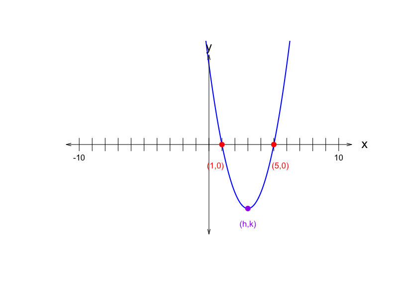

### Factored form

   The polynomial $f(x)$ can be expressed in **factored form**. Which option correctly expresses $f(x)$ in factored form?
   1. $f(x) = (x-{1})\cdot (x+{5})$
   2. $f(x) = (x+{1})\cdot (x-{5})$
   3. $f(x) = (x-{1})\cdot (x-{5})$
   4. $f(x) = (x+{1})\cdot (x+{5})$

### Standard (expanded) form

   The polynomial $f(x)$ can be expressed in **standard form**. Which option correctly expresses $f(x)$ in standard form?
   7. $f(x) = x^{2}-{6}x+{5}$
   8. $f(x) = x^{2}+{6}x+{5}$
   9. $f(x) = x^{2}-{4}x-{5}$
   10. $f(x) = x^{2}+{4}x-{5}$

### Vertex form

   The polynomial $f(x)$ can be expressed in **vertex form**:

   $$f(x)~=~ (x-h)^2+k$$

   where coordinates $(h,k)$ are at the vertex of the parabola (as marked on the graph). Which option correctly expresses $f(x)$ in vertex form?
   16. $f(x)~=~(x+2)^2-9$
   17. $f(x)~=~(x-3)^2-4$
   18. $f(x)~=~(x-2)^2-9$
   19. $f(x)~=~(x+3)^2-4$

#### Question

2. A quadratic polynomial, $f(x)$, is generated by randomly selecting two parameters, $B$ and $C$, in the equation below.

   $$f(x)~=~x^2+Bx+C$$

   Notice the leading coefficient (of the quadratic term) is 1. However the linear coefficient and the constant are randomly determined.

   When $y=f(x)$ is graphed below, you notice it has zeros (roots, $x$-intercepts) at coordinates $(1,0)$ and $(9,0)$.

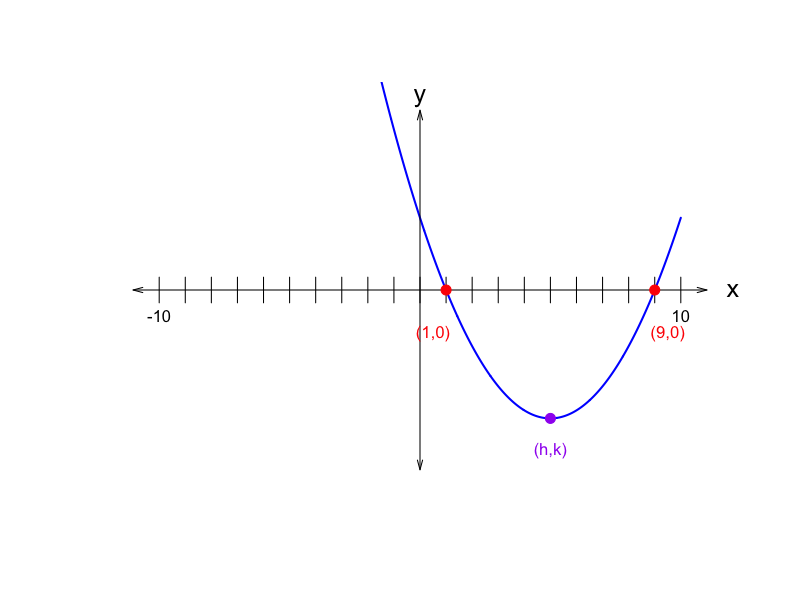

### Factored form

   The polynomial $f(x)$ can be expressed in **factored form**. Which option correctly expresses $f(x)$ in factored form?
   1. $f(x) = (x-{1})\cdot (x+{9})$
   2. $f(x) = (x+{1})\cdot (x-{9})$
   3. $f(x) = (x+{1})\cdot (x+{9})$
   4. $f(x) = (x-{1})\cdot (x-{9})$

### Standard (expanded) form

   The polynomial $f(x)$ can be expressed in **standard form**. Which option correctly expresses $f(x)$ in standard form?
   7. $f(x) = x^{2}+{10}x+{9}$
   8. $f(x) = x^{2}+{8}x-{9}$
   9. $f(x) = x^{2}-{8}x-{9}$
   10. $f(x) = x^{2}-{10}x+{9}$

### Vertex form

   The polynomial $f(x)$ can be expressed in **vertex form**:

   $$f(x)~=~ (x-h)^2+k$$

   where coordinates $(h,k)$ are at the vertex of the parabola (as marked on the graph). Which option correctly expresses $f(x)$ in vertex form?
   16. $f(x)~=~(x-4)^2-25$
   17. $f(x)~=~(x+4)^2-25$
   18. $f(x)~=~(x-5)^2-16$
   19. $f(x)~=~(x+5)^2-16$

#### Question

3. A quadratic polynomial, $f(x)$, is generated by randomly selecting two parameters, $B$ and $C$, in the equation below.

   $$f(x)~=~x^2+Bx+C$$

   Notice the leading coefficient (of the quadratic term) is 1. However the linear coefficient and the constant are randomly determined.

   When $y=f(x)$ is graphed below, you notice it has zeros (roots, $x$-intercepts) at coordinates $(-3,0)$ and $(1,0)$.

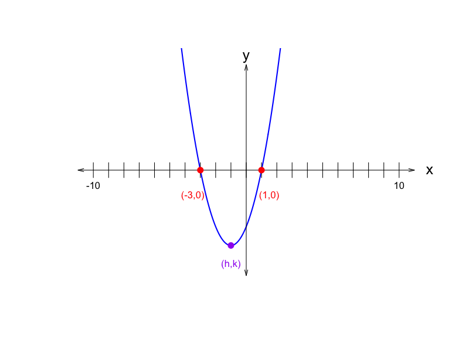

### Factored form

   The polynomial $f(x)$ can be expressed in **factored form**. Which option correctly expresses $f(x)$ in factored form?
   1. $f(x) = (x-{3})\cdot (x+{1})$
   2. $f(x) = (x+{3})\cdot (x+{1})$
   3. $f(x) = (x+{3})\cdot (x-{1})$
   4. $f(x) = (x-{3})\cdot (x-{1})$

### Standard (expanded) form

   The polynomial $f(x)$ can be expressed in **standard form**. Which option correctly expresses $f(x)$ in standard form?
   7. $f(x) = x^{2}-{2}x-{3}$
   8. $f(x) = x^{2}+{4}x+{3}$
   9. $f(x) = x^{2}+{2}x-{3}$
   10. $f(x) = x^{2}-{4}x+{3}$

### Vertex form

   The polynomial $f(x)$ can be expressed in **vertex form**:

   $$f(x)~=~ (x-h)^2+k$$

   where coordinates $(h,k)$ are at the vertex of the parabola (as marked on the graph). Which option correctly expresses $f(x)$ in vertex form?
   16. $f(x)~=~(x-2)^2-1$
   17. $f(x)~=~(x+1)^2-4$
   18. $f(x)~=~(x+2)^2-1$
   19. $f(x)~=~(x-1)^2-4$

#### Question

4. A quadratic polynomial, $f(x)$, is generated by randomly selecting two parameters, $B$ and $C$, in the equation below.

   $$f(x)~=~x^2+Bx+C$$

   Notice the leading coefficient (of the quadratic term) is 1. However the linear coefficient and the constant are randomly determined.

   When $y=f(x)$ is graphed below, you notice it has zeros (roots, $x$-intercepts) at coordinates $(-6,0)$ and $(8,0)$.

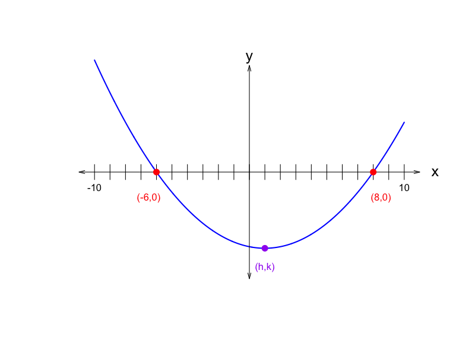

### Factored form

   The polynomial $f(x)$ can be expressed in **factored form**. Which option correctly expresses $f(x)$ in factored form?
   1. $f(x) = (x-{6})\cdot (x-{8})$
   2. $f(x) = (x+{6})\cdot (x+{8})$
   3. $f(x) = (x-{6})\cdot (x+{8})$
   4. $f(x) = (x+{6})\cdot (x-{8})$

### Standard (expanded) form

   The polynomial $f(x)$ can be expressed in **standard form**. Which option correctly expresses $f(x)$ in standard form?
   7. $f(x) = x^{2}-{2}x-{48}$
   8. $f(x) = x^{2}+{2}x-{48}$
   9. $f(x) = x^{2}+{14}x+{48}$
   10. $f(x) = x^{2}-{14}x+{48}$

### Vertex form

   The polynomial $f(x)$ can be expressed in **vertex form**:

   $$f(x)~=~ (x-h)^2+k$$

   where coordinates $(h,k)$ are at the vertex of the parabola (as marked on the graph). Which option correctly expresses $f(x)$ in vertex form?
   16. $f(x)~=~(x-7)^2-1$
   17. $f(x)~=~(x+7)^2-1$
   18. $f(x)~=~(x+1)^2-49$
   19. $f(x)~=~(x-1)^2-49$

#### Question

5. A quadratic polynomial, $f(x)$, is generated by randomly selecting two parameters, $B$ and $C$, in the equation below.

   $$f(x)~=~x^2+Bx+C$$

   Notice the leading coefficient (of the quadratic term) is 1. However the linear coefficient and the constant are randomly determined.

   When $y=f(x)$ is graphed below, you notice it has zeros (roots, $x$-intercepts) at coordinates $(3,0)$ and $(7,0)$.

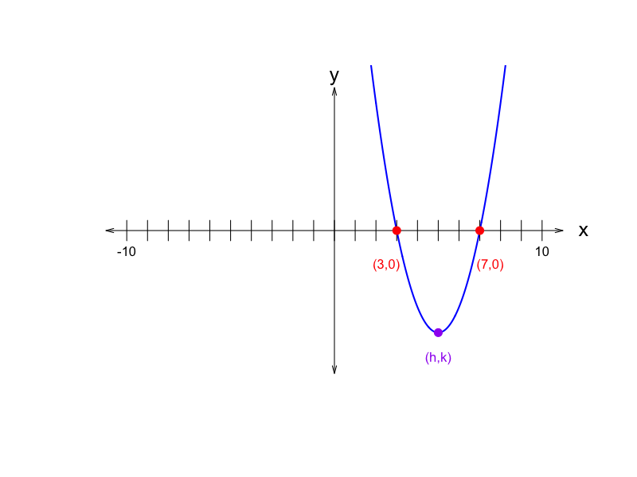

### Factored form

   The polynomial $f(x)$ can be expressed in **factored form**. Which option correctly expresses $f(x)$ in factored form?
   1. $f(x) = (x-{3})\cdot (x-{7})$
   2. $f(x) = (x+{3})\cdot (x+{7})$
   3. $f(x) = (x+{3})\cdot (x-{7})$
   4. $f(x) = (x-{3})\cdot (x+{7})$

### Standard (expanded) form

   The polynomial $f(x)$ can be expressed in **standard form**. Which option correctly expresses $f(x)$ in standard form?
   7. $f(x) = x^{2}+{4}x-{21}$
   8. $f(x) = x^{2}-{10}x+{21}$
   9. $f(x) = x^{2}-{4}x-{21}$
   10. $f(x) = x^{2}+{10}x+{21}$

### Vertex form

   The polynomial $f(x)$ can be expressed in **vertex form**:

   $$f(x)~=~ (x-h)^2+k$$

   where coordinates $(h,k)$ are at the vertex of the parabola (as marked on the graph). Which option correctly expresses $f(x)$ in vertex form?
   16. $f(x)~=~(x-2)^2-25$
   17. $f(x)~=~(x+5)^2-4$
   18. $f(x)~=~(x+2)^2-25$
   19. $f(x)~=~(x-5)^2-4$

#### Question

6. A quadratic polynomial, $f(x)$, is generated by randomly selecting two parameters, $B$ and $C$, in the equation below.

   $$f(x)~=~x^2+Bx+C$$

   Notice the leading coefficient (of the quadratic term) is 1. However the linear coefficient and the constant are randomly determined.

   When $y=f(x)$ is graphed below, you notice it has zeros (roots, $x$-intercepts) at coordinates $(-3,0)$ and $(1,0)$.

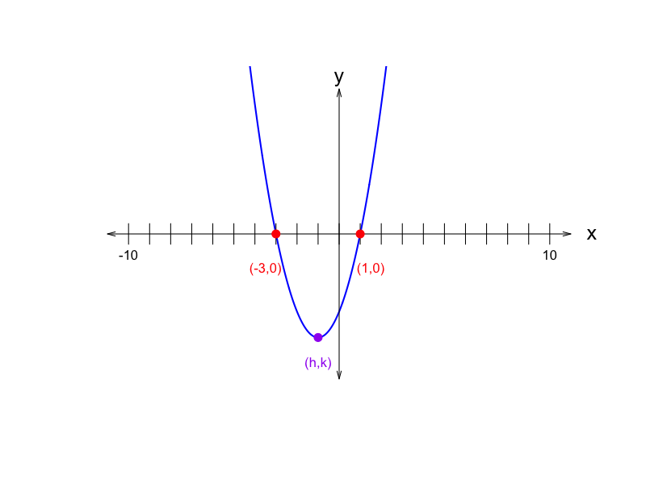

### Factored form

   The polynomial $f(x)$ can be expressed in **factored form**. Which option correctly expresses $f(x)$ in factored form?
   1. $f(x) = (x+{3})\cdot (x+{1})$
   2. $f(x) = (x+{3})\cdot (x-{1})$
   3. $f(x) = (x-{3})\cdot (x-{1})$
   4. $f(x) = (x-{3})\cdot (x+{1})$

### Standard (expanded) form

   The polynomial $f(x)$ can be expressed in **standard form**. Which option correctly expresses $f(x)$ in standard form?
   7. $f(x) = x^{2}-{2}x-{3}$
   8. $f(x) = x^{2}-{4}x+{3}$
   9. $f(x) = x^{2}+{2}x-{3}$
   10. $f(x) = x^{2}+{4}x+{3}$

### Vertex form

   The polynomial $f(x)$ can be expressed in **vertex form**:

   $$f(x)~=~ (x-h)^2+k$$

   where coordinates $(h,k)$ are at the vertex of the parabola (as marked on the graph). Which option correctly expresses $f(x)$ in vertex form?
   16. $f(x)~=~(x-1)^2-4$
   17. $f(x)~=~(x+1)^2-4$
   18. $f(x)~=~(x+2)^2-1$
   19. $f(x)~=~(x-2)^2-1$

#### Question

7. A quadratic polynomial, $f(x)$, is generated by randomly selecting two parameters, $B$ and $C$, in the equation below.

   $$f(x)~=~x^2+Bx+C$$

   Notice the leading coefficient (of the quadratic term) is 1. However the linear coefficient and the constant are randomly determined.

   When $y=f(x)$ is graphed below, you notice it has zeros (roots, $x$-intercepts) at coordinates $(1,0)$ and $(7,0)$.

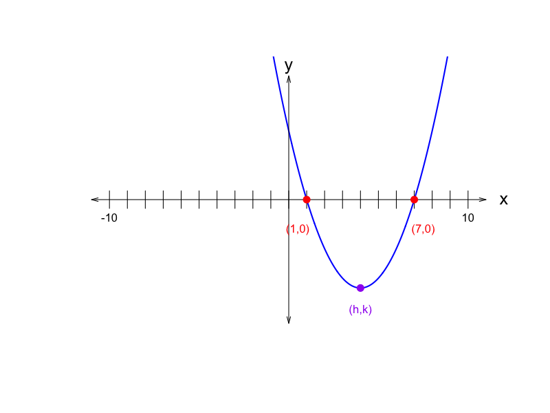

### Factored form

   The polynomial $f(x)$ can be expressed in **factored form**. Which option correctly expresses $f(x)$ in factored form?
   1. $f(x) = (x-{1})\cdot (x-{7})$
   2. $f(x) = (x+{1})\cdot (x-{7})$
   3. $f(x) = (x+{1})\cdot (x+{7})$
   4. $f(x) = (x-{1})\cdot (x+{7})$

### Standard (expanded) form

   The polynomial $f(x)$ can be expressed in **standard form**. Which option correctly expresses $f(x)$ in standard form?
   7. $f(x) = x^{2}-{8}x+{7}$
   8. $f(x) = x^{2}+{6}x-{7}$
   9. $f(x) = x^{2}-{6}x-{7}$
   10. $f(x) = x^{2}+{8}x+{7}$

### Vertex form

   The polynomial $f(x)$ can be expressed in **vertex form**:

   $$f(x)~=~ (x-h)^2+k$$

   where coordinates $(h,k)$ are at the vertex of the parabola (as marked on the graph). Which option correctly expresses $f(x)$ in vertex form?
   16. $f(x)~=~(x-3)^2-16$
   17. $f(x)~=~(x+3)^2-16$
   18. $f(x)~=~(x-4)^2-9$
   19. $f(x)~=~(x+4)^2-9$

#### Question

8. A quadratic polynomial, $f(x)$, is generated by randomly selecting two parameters, $B$ and $C$, in the equation below.

   $$f(x)~=~x^2+Bx+C$$

   Notice the leading coefficient (of the quadratic term) is 1. However the linear coefficient and the constant are randomly determined.

   When $y=f(x)$ is graphed below, you notice it has zeros (roots, $x$-intercepts) at coordinates $(-9,0)$ and $(5,0)$.

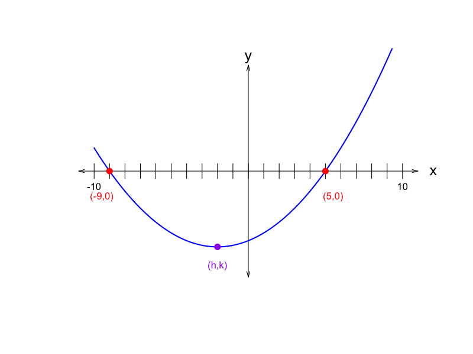

### Factored form

   The polynomial $f(x)$ can be expressed in **factored form**. Which option correctly expresses $f(x)$ in factored form?
   1. $f(x) = (x-{9})\cdot (x+{5})$
   2. $f(x) = (x+{9})\cdot (x+{5})$
   3. $f(x) = (x+{9})\cdot (x-{5})$
   4. $f(x) = (x-{9})\cdot (x-{5})$

### Standard (expanded) form

   The polynomial $f(x)$ can be expressed in **standard form**. Which option correctly expresses $f(x)$ in standard form?
   7. $f(x) = x^{2}-{14}x+{45}$
   8. $f(x) = x^{2}+{14}x+{45}$
   9. $f(x) = x^{2}+{4}x-{45}$
   10. $f(x) = x^{2}-{4}x-{45}$

### Vertex form

   The polynomial $f(x)$ can be expressed in **vertex form**:

   $$f(x)~=~ (x-h)^2+k$$

   where coordinates $(h,k)$ are at the vertex of the parabola (as marked on the graph). Which option correctly expresses $f(x)$ in vertex form?
   16. $f(x)~=~(x-7)^2-4$
   17. $f(x)~=~(x+2)^2-49$
   18. $f(x)~=~(x-2)^2-49$
   19. $f(x)~=~(x+7)^2-4$